# Mapping

Team 1 - Mapping

##Load Libraries

Here we loaded a few libraries we will be needing

```r
library(tidyverse)
library(dsbox)
library(lubridate)
library(janitor)
library(here)
```

##Our Goals Team 1 - Mapping

Task 1 - Revisit what we have done with maps. Identify where we have made maps in the class, and what packages we have used.

Task 2 - Make a plot of at least some subset of the datapoints from the bike share data.

We will want to use the `sf` package. See if you can find a tutorial that is “our speed.”

We will want to use the `tmap` package. See if you can find a tutorial that is “our speed.”

##Answering Task 1

-We have made maps in class.

-We made a map in Lab 04. There were maps per state, and maps of the entire US.

-Some classmates were able to generate a plot in Lab 04 on an actual interactive map. This map included borders, and ability to zoom in and out. (Was it Shreejit?) How was this done? It could be a useful tool.

-The packages used in lab 04 were tidyverse and and dsbox

##Task 2 Here the goal is to make a plot of a subset of the datapoints from the bike share data.

Our subset will be the locations of pick-ups and drop-offs for Saturday September 4, 2021

```r
df1 <- read_csv(here("submissions","bike_share","data","202109-capitalbikeshare-tripdata.csv")) %>% clean_names()
```

Here We want to get the data filtered to just Sep 4

```r
df1a = df1 %>%
  select(rideable_type, start = started_at, end = ended_at, start_station_name:end_lng) %>%
  pivot_longer(cols =  start:end,  names_to = "type", values_to = "time")%>%
  arrange(time) %>%
  mutate(inc = case_when(
    type == "start" ~ 1,
    type == "end" ~ -1
  ), riders = cumsum(inc)) %>%
  mutate(day_of_year = yday(time)) %>%
  mutate(day_since_sep1 = day_of_year-243) %>%
  filter(day_since_sep1 == 4)
```

Here is the visualization

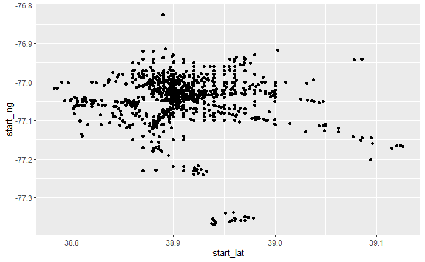

```r
ggplot(df1a, mapping = aes(x = start_lat, y = start_lng)) +
  geom_point()
```

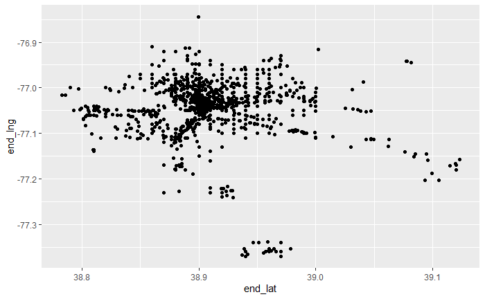

```r
ggplot(df1a, mapping = aes(x = end_lat, y = end_lng)) +
  geom_point()
```

It would be beneficial if this plot were overlaid over some map of the city. Right now the points do not mean much.